# Homework9

Nicole R Gorman

2024-03-30

##Organizing Code With Structured Programming

- Open libraries

```r
library(tidyverse)
library(ggplot2)
library(MASS)
```

- Use the code that you worked on in Homework #7 (creating fake data sets), and re-organize it following the principles of structured programming.
- Do all the work in a single chunk in your R markdown file, just as if you were writing a single R script.
- Start with all of your annotated functions, preliminary calls, and global variables.
- The program body should be only a few lines of code that call the appropriate functions and run them in the correct order.
- Make sure that the output from one function serves as the input to the next. You can either daisy-chain the functions or write separate lines of code to hold elements in temporary variables and pass them along.

```r
# Read in the data
setwd("~/Documents/UVM_Research/UVM Rotation Project/ACC Trials")
x<-list.files(pattern="HW9")
```

```r
# call the new functions with my data set as an argument
source("Homework9Function.R")
```

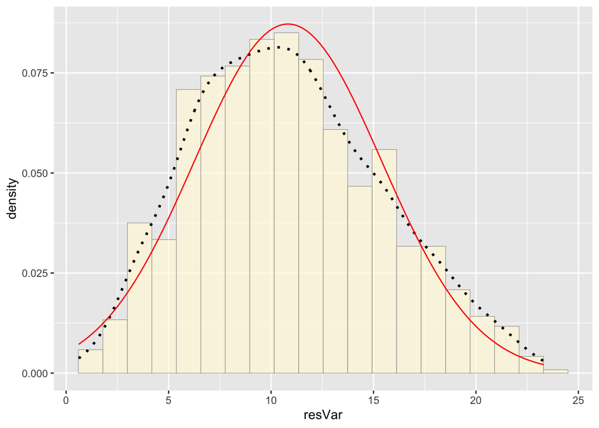

```
## $summary
##    Min. 1st Qu.  Median    Mean 3rd Qu.    Max.
##   0.610   7.342  10.520  10.829  13.943  23.310
##
## $norm_pars
##      mean        sd
## 10.828933  4.571444
##
##              Df Sum Sq Mean Sq F value   Pr(>F)
## Group         5    594  118.84   5.817 2.64e-05 ***
## Residuals   998  20387   20.43
## ---
## Signif. codes:  0 '***' 0.001 '**' 0.01 '*' 0.05 '.' 0.1 ' ' 1
```

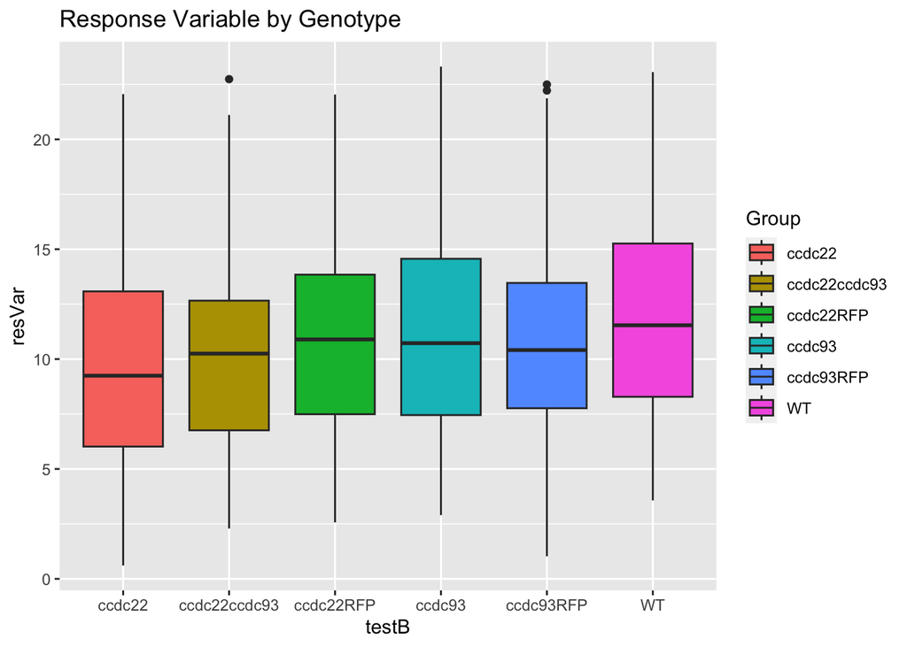

[figure not shown]

```r
my_data <- cln_dat("ACCData_HW9.csv", "genotype", "treatment", "length")
# returns clean data set
```

```r
result <- dat_stat(my_data,"resVar")
```

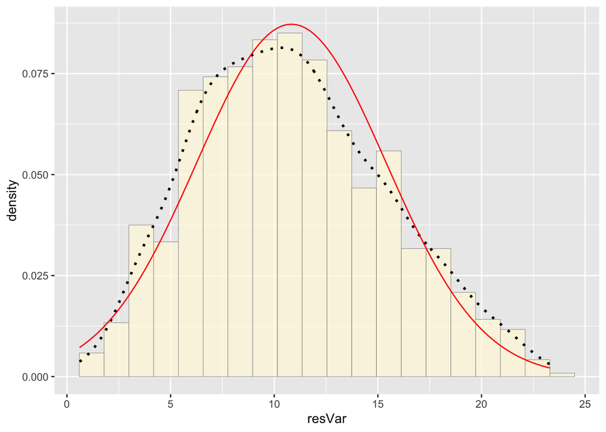

```r
print(result)
```

```
## $summary
##    Min. 1st Qu.  Median    Mean 3rd Qu.    Max.
##   0.610   7.342  10.520  10.829  13.943  23.310
##
## $norm_pars
##      mean        sd
## 10.828933  4.571444
```

```r
# returns histogram and summary statistics
```

```r
results <- do_anova(my_data, "resVar", "testB")
# Perform ANOVA and create box plot
```

- Once your code is up and working, modify your program to do something else: record a new summary variable, code a new statistical analysis, or create a different set of random variables or output graph.
- Do not rewrite any of your existing functions. Instead, copy them, rename them, and then modify them to do new things.
- Once your new functions are written, add some more lines of program code, calling a mixture of your previous functions and your new functions to get the job done.

```r
# call original do_ANOVA function with boxplot, change grouping

results <- do_anova(my_data, "resVar", "testB")
# Perform ANOVA and create box plot
# Grouping by hormone treatment instead on genotype

print(results$ANOVA_summary)
```

```
##               Df Sum Sq Mean Sq F value Pr(>F)
## Group          3   1956   652.1   34.27 <2e-16 ***
## Residuals   1000  19025    19.0
## ---
## Signif. codes:  0 '***' 0.001 '**' 0.01 '*' 0.05 '.' 0.1 ' ' 1
```

[figure not shown]

```r
# Print ANOVA summary

print(results$boxplot)
```

```r
# Print box plot
```

[figure not shown]

```r
# call a modified function to make a bargraph instead of a boxplot.
# Pretty lame, but I finally got the code to run...considering this a victory :)

results <- do_anova2(my_data, "resVar", "testB")
```

```r
# Perform ANOVA and create bar plot
# Using hormone treatment for grouping

print(results$barplot)
```

```r
# Print bar plot
```